# SI 370 - Homework #3: Applied Statistics

### Name: Samantha Cohen

### Uniqname: samcoh

## Background

This homework assignment focuses on data from the [World Happiness Report](https://www.kaggle.com/unsdsn/world-happiness).

The World Happiness Report is a landmark survey of the state of global happiness. The first report was published in 2012, the second in 2013, the third in 2015, and the fourth in the 2016 Update. The World Happiness 2017, which ranks 155 countries by their happiness levels, was released at the United Nations at an event celebrating International Day of Happiness on March 20th. The report continues to gain global recognition as governments, organizations and civil society increasingly use happiness indicators to inform their policy-making decisions. Leading experts across fields – economics, psychology, survey analysis, national statistics, health, public policy and more – describe how measurements of well-being can be used effectively to assess the progress of nations. The reports review the state of happiness in the world today and show how the new science of happiness explains personal and national variations in happiness.

We will be using data from the 2016 report.

Your main task in this assignment is to explore the data *using the data manipulation, analysis, visualization, and applied statistical methods we covered in class* as well as those in the assigned readings.

**You should also feel free to ask questions on the **[class Slack channel](https://si370fa2018.slack.com/messages/CCQLTNS65/team/UCFLDB049/)** !**

A total of 30 points is available in this homework assignment.

Questions 1-6 are worth 5 points each. Points will be allocated according to the following rubric:

- 5 points: Question is correctly and completely answered. Answer consists of well-written code that conforms to [PEP 8](https://www.python.org/dev/peps/pep-0008/) guidelines and is accompanied by a written interpretation in a Markdown block. Written interpretation does not contain spelling, grammar or stylistic errors (see https://faculty.washington.edu/heagerty/Courses/b572/public/StrunkWhite.pdf for a detailed specifications).
- 4 points: Answer is mostly complete and correct; two or fewer noticeable omissions or errors. Minor stylistic flaws, either in code or in written interpretation.
- 3 points: Answer has significant omissions or errors; Noticeable departure from PEP-8 guidelines and/or moderate spelling, grammar, or style issues in written interpretations.
- 2 points: Question is perfunctorily attempted. Substantial parts are missing or incorrect.
- 0 points: Question not attempted.

```python
import pandas as pd
import numpy as np
import matplotlib.pyplot as plt
import seaborn as sns
import statsmodels
import statsmodels.api as sm
from statsmodels.formula.api import ols
import statsmodels.formula.api as smf
from scipy import stats
import warnings
from scipy.stats import chi2_contingency
from statsmodels.formula.api import ols

# import statsmodels.api as sm
# import statsmodels.formula.api as smf
# from statsmodels.formula.api import ols
from statsmodels.graphics.mosaicplot import mosaic
```

```python
warnings.filterwarnings('ignore') #ignore warnings... they were so annoying
```

```python
happiness = pd.read_csv('data/world-happiness-2016.csv')
```

```python
happiness.shape
```

```
(157, 13)
```

```python
happiness.head(20)
```

|  | Country | Region | Happiness Rank | Happiness Score | Lower Confidence Interval | Upper Confidence Interval | Economy (GDP per Capita) | Family | Health (Life Expectancy) | Freedom | Trust (Government Corruption) | Generosity | Dystopia Residual |
| --- | --- | --- | --- | --- | --- | --- | --- | --- | --- | --- | --- | --- | --- |
| 0 | Denmark | Western Europe | 1 | 7.526 | 7.460 | 7.592 | 1.44178 | 1.16374 | 0.79504 | 0.57941 | 0.44453 | 0.36171 | 2.73939 |
| 1 | Switzerland | Western Europe | 2 | 7.509 | 7.428 | 7.590 | 1.52733 | 1.14524 | 0.86303 | 0.58557 | 0.41203 | 0.28083 | 2.69463 |
| 2 | Iceland | Western Europe | 3 | 7.501 | 7.333 | 7.669 | 1.42666 | 1.18326 | 0.86733 | 0.56624 | 0.14975 | 0.47678 | 2.83137 |
| 3 | Norway | Western Europe | 4 | 7.498 | 7.421 | 7.575 | 1.57744 | 1.12690 | 0.79579 | 0.59609 | 0.35776 | 0.37895 | 2.66465 |
| 4 | Finland | Western Europe | 5 | 7.413 | 7.351 | 7.475 | 1.40598 | 1.13464 | 0.81091 | 0.57104 | 0.41004 | 0.25492 | 2.82596 |
| 5 | Canada | North America | 6 | 7.404 | 7.335 | 7.473 | 1.44015 | 1.09610 | 0.82760 | 0.57370 | 0.31329 | 0.44834 | 2.70485 |
| 6 | Netherlands | Western Europe | 7 | 7.339 | 7.284 | 7.394 | 1.46468 | 1.02912 | 0.81231 | 0.55211 | 0.29927 | 0.47416 | 2.70749 |
| 7 | New Zealand | Australia and New Zealand | 8 | 7.334 | 7.264 | 7.404 | 1.36066 | 1.17278 | 0.83096 | 0.58147 | 0.41904 | 0.49401 | 2.47553 |
| 8 | Australia | Australia and New Zealand | 9 | 7.313 | 7.241 | 7.385 | 1.44443 | 1.10476 | 0.85120 | 0.56837 | 0.32331 | 0.47407 | 2.54650 |
| 9 | Sweden | Western Europe | 10 | 7.291 | 7.227 | 7.355 | 1.45181 | 1.08764 | 0.83121 | 0.58218 | 0.40867 | 0.38254 | 2.54734 |
| 10 | Israel | Middle East and Northern Africa | 11 | 7.267 | 7.199 | 7.335 | 1.33766 | 0.99537 | 0.84917 | 0.36432 | 0.08728 | 0.32288 | 3.31029 |
| 11 | Austria | Western Europe | 12 | 7.119 | 7.045 | 7.193 | 1.45038 | 1.08383 | 0.80565 | 0.54355 | 0.21348 | 0.32865 | 2.69343 |
| 12 | United States | North America | 13 | 7.104 | 7.020 | 7.188 | 1.50796 | 1.04782 | 0.77900 | 0.48163 | 0.14868 | 0.41077 | 2.72782 |
| 13 | Costa Rica | Latin America and Caribbean | 14 | 7.087 | 6.999 | 7.175 | 1.06879 | 1.02152 | 0.76146 | 0.55225 | 0.10547 | 0.22553 | 3.35168 |
| 14 | Puerto Rico | Latin America and Caribbean | 15 | 7.039 | 6.794 | 7.284 | 1.35943 | 1.08113 | 0.77758 | 0.46823 | 0.12275 | 0.22202 | 3.00760 |
| 15 | Germany | Western Europe | 16 | 6.994 | 6.930 | 7.058 | 1.44787 | 1.09774 | 0.81487 | 0.53466 | 0.28551 | 0.30452 | 2.50931 |
| 16 | Brazil | Latin America and Caribbean | 17 | 6.952 | 6.875 | 7.029 | 1.08754 | 1.03938 | 0.61415 | 0.40425 | 0.14166 | 0.15776 | 3.50733 |
| 17 | Belgium | Western Europe | 18 | 6.929 | 6.861 | 6.997 | 1.42539 | 1.05249 | 0.81959 | 0.51354 | 0.26248 | 0.24240 | 2.61355 |
| 18 | Ireland | Western Europe | 19 | 6.907 | 6.836 | 6.978 | 1.48341 | 1.16157 | 0.81455 | 0.54008 | 0.29754 | 0.44963 | 2.15988 |
| 19 | Luxembourg | Western Europe | 20 | 6.871 | 6.804 | 6.938 | 1.69752 | 1.03999 | 0.84542 | 0.54870 | 0.35329 | 0.27571 | 2.11055 |

## Answer the questions below.

For each question, you should

1. Write code that can help you answer the following questions, and
2. Explain your answers in plain English. You should use complete sentences that would be understood by an educated professional who is not necessarily a data scientist (like a product manager).

# Q1: What are the top 5 correlation coefficients among "Happiness Score", Economy, Family, Health, Freedom, Trust, and Generosity? Provide a visualization as well as a written statement of your findings. (5 points)

#### 1) Look at the columns in the happiness DataFrame to get the correct column names that are asked for in the question: Happiness Score, Economy, Family, Health, Freedom, Trust, and Generosity

```python
happiness.columns
```

```
Index(['Country', 'Region', 'Happiness Rank', 'Happiness Score',
       'Lower Confidence Interval', 'Upper Confidence Interval',
       'Economy (GDP per Capita)', 'Family', 'Health (Life Expectancy)',
       'Freedom', 'Trust (Government Corruption)', 'Generosity',
       'Dystopia Residual'],
      dtype='object')
```

##### Explanation:

Found that the names of the columns I want include:

1. "Happiness Score"
2. "Economy (GDP per Capita)"
3. "Family"
4. "Health (Life Expectancy)"
5. "Freedom"
6. "Trust (Government Corruption)"
7. "Generosity"

#### 2) Create a DataFrame called subset that has only variables you want in your visualization: Happiness Score, Economy, Family, Health, Freedom, Trust, and Generosity

```python
subset = happiness[["Happiness Score", "Economy (GDP per Capita)", "Family", "Health (Life Expectancy)", "Freedom", "Trust (Government Corruption)", "Generosity"]]
```

#### 3) Get a DataFrame that shows the correlation of these varaibles by using the .corr() method

```python
correlation = subset.corr()
```

#### Explanation:

The corr method in pandas computers the pairwise correlation of columns and excludes the null values (https://pandas.pydata.org/pandas-docs/stable/reference/api/pandas.DataFrame.corr.html)

By using .corr on the subset DataFrame it creates a DataFrame that shows the correlation across all the different variable combinations.

#### 4) Create a HeatMap visualization of the correlations

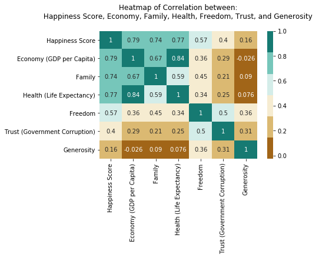

```python
ax = plt.axes()
sns.heatmap(correlation, cmap= sns.color_palette("BrBG"), annot=True)
ax.set_title('Heatmap of Correlation between:\n Happiness Score, Economy, Family, Health, Freedom, Trust, and Generosity \n')
```

##### Explanation:

I chose to use a heatmap because as learned in lecture heatmaps are useful visualization techniques for large correlation matrices. I changed the colors from the deafult color values because it was hard to see the differences in correlations.

As you can see the dignoal line across the heatmap (in blue) shows that every varaible is 100 percent related to itself. You can also see the top 5 correlations:

1. Health (Life Expectancy) and Economy (GDP per Capita): 0.837067
2. Happiness Score and Economy (GDP per Capita): 0.790322
3. Happiness Score and Health (Life Expectancy): 0.765384
4. Happiness Score and Family: 0.739252
5. Economy (GDP per Capita) and Family: 0.669540

A correlation is how close two variables are to having a linear relationship with each other. All of these combination variables have a strong positive correlation. I further confirmed these correlations by printing the top 10 correlations in the code below (because there are 5 repeats).

```python
s = correlation.abs()
s=s.unstack()  #unstack the dataframe
so = s.sort_values(ascending = False)
top_10 =so[so < 1.0].head(10)
print(top_10)
```

```
Health (Life Expectancy)  Economy (GDP per Capita)    0.837067
Economy (GDP per Capita)  Health (Life Expectancy)    0.837067
Happiness Score           Economy (GDP per Capita)    0.790322
Economy (GDP per Capita)  Happiness Score             0.790322
Happiness Score           Health (Life Expectancy)    0.765384
Health (Life Expectancy)  Happiness Score             0.765384
Happiness Score           Family                      0.739252
Family                    Happiness Score             0.739252
Economy (GDP per Capita)  Family                      0.669540
Family                    Economy (GDP per Capita)    0.669540
dtype: float64
```

1. Health (Life Expectancy) and Economy (GDP per Capita): 0.837067
2. Happiness Score and Economy (GDP per Capita): 0.790322
3. Happiness Score and Health (Life Expectancy): 0.765384
4. Happiness Score and Family: 0.739252
5. Economy (GDP per Capita) and Family: 0.669540

# Q2: Describe, using plots, the relationships between the following variables: (5 points)

1. Happiness vs. Family
2. Happiness vs. Economy
3. Happiness vs. Health
4. Happiness vs. Freedom
5. Happiness vs. Trust
6. Happiness vs. Generosity

You have, at this point, a wide variety of visualizations that you know how to generate. Choose wisely!

#### 1) Create a DataFrame called subset with only the columns that will be used for the visualizations: Happiness Score, Family, Economy (GDP per Capita),Health (Life Expectancy), Freedom, Trust (Government Corruption), and Generosity

```python
subset = happiness[["Happiness Score", "Family", "Economy (GDP per Capita)","Health (Life Expectancy)", "Freedom", "Trust (Government Corruption)", "Generosity"]]
```

#### 2) Create a scatterplot pairplot that plots "Family", "Economy (GDP per Capita)","Health (Life Expectancy)", "Freedom", "Trust (Government Corruption)", "Generosity" on the x-axis and Happiness on the y-axis. Afterwards, create the same plots but put Happiness Score on the x-axis, and "Family", "Economy (GDP per Capita)","Health (Life Expectancy)", "Freedom", "Trust (Government Corruption)", "Generosity" on the y-axis.

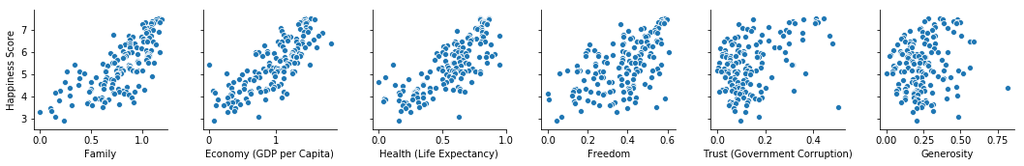

```python
#subset = happiness[["Happiness Score", "Family", "Economy (GDP per Capita)","Health (Life Expectancy)", "Freedom", "Trust (Government Corruption)", "Generosity"]]
g2=sns.pairplot(y_vars=["Happiness Score"] ,
             x_vars= ["Family", "Economy (GDP per Capita)","Health (Life Expectancy)", "Freedom", "Trust (Government Corruption)", "Generosity"],
             data = subset,
             kind="scatter")
```

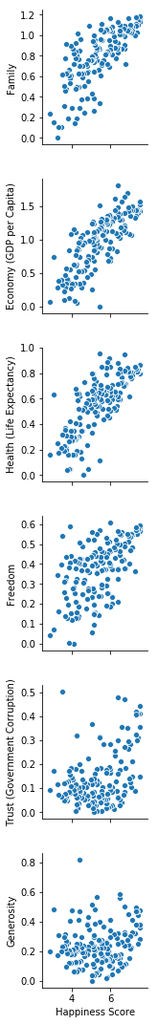

```python
g2=sns.pairplot(x_vars=["Happiness Score"] ,
             y_vars= ["Family", "Economy (GDP per Capita)","Health (Life Expectancy)", "Freedom", "Trust (Government Corruption)", "Generosity"],
             data = subset,
             kind="scatter")
```

##### Explanation:

**1. Happiness vs. Family**

Happiness Sore and Family seem like they could have a correlation. This is because it appears that as happiness score increases so does Family.

**2. Happiness vs. Economy**

Happiness Sore and Economy seem like they could have a correlation. This is because it appears that as happiness score increases so does Economy (GDP per Capita).

**3. Happiness vs. Health**

Happiness Sore and Health seem like they could have a correlation. This is because it appears that as happiness score increases so does Health.

**4. Happiness vs. Freedom**

Happiness Sore and Freedom seem like they could have a correlation. This is because it appears that as happiness score increases so does Freedom. Although, the distance between the points are spread out, so this may indicate that there is not a strong correlation.

**5. Happiness vs. Trust**

Happiness Sore and Trust (Government Corruption) do not seem to have a correlation. This is because it does not appear that as happiness score increases so does Trust (Government Corruption), or as happiness score decreases so does Trust (Government Corruption). The overall shape of the plot is almost round, and the points do not have much direction.

**6. Happiness vs. Generosity**

Happiness Sore and generoisty do not seem to have a strong correlation. This is because it does not appear that as happiness score increases so does Generosity, or happiness score decreases so does Generosity. The overall shape of the plot is almost round, and the points do not have much direction.

#### 3) Now, create a regression model pairplot that shows the linear regression of "Family", "Economy (GDP per Capita)","Health (Life Expectancy)", "Freedom", "Trust (Government Corruption)", "Generosity" on the x-axis and Happiness on the y-axis. Afterwards, create the same plots but put Happiness Score on the x-axis, and "Family", "Economy (GDP per Capita)","Health (Life Expectancy)", "Freedom", "Trust (Government Corruption)", "Generosity" on the y-axis.

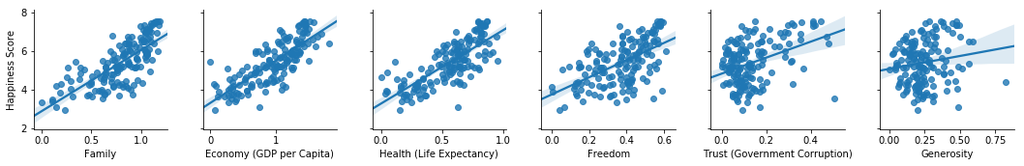

```python
#subset = happiness[["Happiness Score", "Family", "Economy (GDP per Capita)","Health (Life Expectancy)", "Freedom", "Trust (Government Corruption)", "Generosity"]]
g2=sns.pairplot(y_vars=["Happiness Score"],
                x_vars= ["Family", "Economy (GDP per Capita)","Health (Life Expectancy)", "Freedom", "Trust (Government Corruption)", "Generosity"],
                data = subset,
                kind="reg",
                )
```

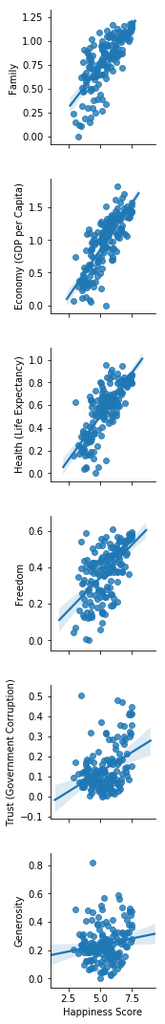

```python
g2=sns.pairplot(x_vars=["Happiness Score"],
                y_vars= ["Family", "Economy (GDP per Capita)","Health (Life Expectancy)", "Freedom", "Trust (Government Corruption)", "Generosity"],
                data = subset,
                kind="reg",
                )
```

##### Explanation:

**1. Happiness vs. Family**

Happiness Sore and Family appear to have a correlation. This is because it appears that as happiness score increases so does Family.

**2. Happiness vs. Economy**

Happiness Sore and Economy appear to have a correlation. This is because it appears that as happiness score increases so does Economy (GDP per Capita).

**3. Happiness vs. Health**

Happiness Sore and Health appear to have a correlation. This is because it appears that as happiness score increases so does Health.

**4. Happiness vs. Freedom**

Happiness Sore and Freedom appear to have a correlation. This is because it appears that as happiness score increases so does Freedom. Although the distance between the points are spread out, so this may indicate that there is not a strong correlation.

**5. Happiness vs. Trust**

Happiness Sore and Trust (Government Corruption) do not appear to have a correlation. This is because it does not appear that as happiness score increases so does Trust (Government Corruption), or as happiness score decreases so does Trust (Government Corruption). The overall shape of the plot is almost round, and the points do not have much direction.

**6. Happiness vs. Generosity**

Happiness Sore and generoisty do not appear to have a correlation. This is because it does not appear that as happiness score increases so does Generosity, or as happiness score decreases so does Generosity. The overall shape of the plot is almost round, and the points do not have much direction.

#### 4) Finally, create JointGrid Visualizations that show the p-value and personr score for all the different relationships:

1. Happiness vs. Family
2. Happiness vs. Economy
3. Happiness vs. Health
4. Happiness vs. Freedom
5. Happiness vs. Trust
6. Happiness vs. Generosity

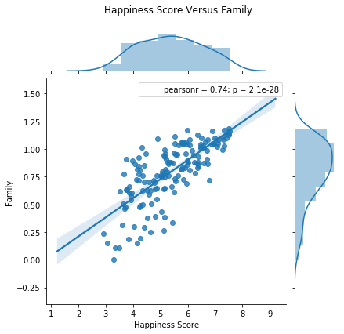

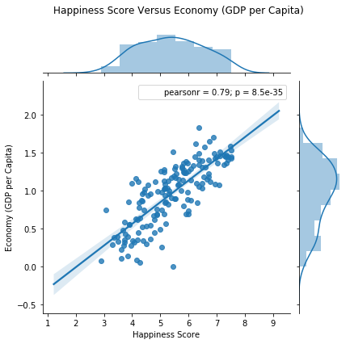

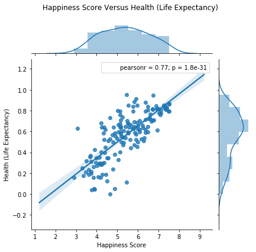

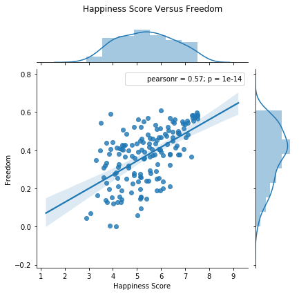

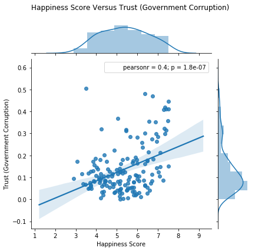

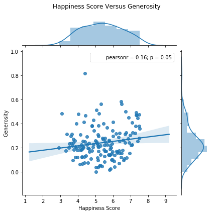

```python
for column in subset.columns:
    if column != "Happiness Score":
        g2 = sns.JointGrid(data=subset,x='Happiness Score',y=column)
        g2.plot(sns.regplot, sns.distplot)
        g2.annotate(stats.pearsonr)
        g2.fig.subplots_adjust(top=0.9)
        g2.fig.suptitle("Happiness Score Versus {}".format(column), fontsize=12)
```

#### Explanation:

The Pearson correlation coefficient (located in the top right of each visualization) measures the linear relationship between two datasets. The calculation of the p-value relies on the assumption that each dataset is normally distributed. According to https://docs.scipy.org/doc/scipy/reference/generated/scipy.stats.pearsonr.html, "Like other correlation coefficients, this one varies between -1 and +1 with 0 implying no correlation. Correlations of -1 or +1 imply an exact linear relationship. Positive correlations imply that as x increases, so does y. Negative correlations imply that as x increases, y decreases. The p-value roughly indicates the probability of an uncorrelated system producing datasets that have a Pearson correlation at least as extreme as the one computed from these datasets."

**1. Happiness vs. Family**

Happiness Sore and Family have a correlation. This is because as happiness score increases so does Family. The personr value calculated shows if the two variables have a correlation. The personr for Happiness Score versus Family is 0.74, indicating that there is a strong linear relationship/correlation present. The p-value of 2.1e-28 is less than 0.05. This means that this is a statistically significant model, and we can reject the null hypothesis.

**2. Happiness vs. Economy**

Happiness Sore and Economy have a correlation. This is because it appears that as happiness score increases so does Economy (GDP per Capita). The personr for Happiness Score versus Economy is 0.79, indicating that there is a strong linear relationship present. The p-value of 8.5-35 is less than 0.05. This means that this is a statistically significant model, and we can reject the null hypothesis.

**3. Happiness vs. Health**

Happiness Sore and Freedom appear to have a correlation. This is because it appears that as happiness score increases so does Freedom. The personr for Happiness Score versus Freedom is 0.57, indicating that there is a moderate linear relationship present/correlation. The p-value of 1e-14 is less than 0.05. This means that this is a statistically significant model, and we can reject the null hypothesis.

**6. Happiness vs. Generosity**

Happiness Sore and generoisty have a very weak correlation. The personr for Happiness Score versus Generosity is 0.16, indicating that there is a very weak linear relationship/correlation present. The p-value of 0.05 is not less than 0.05. This means that this is *not* a statistically significant model, and we do not reject the null hyopothesis.

# Q3: Does there appear to be an interaction between region and happiness quartile? (5 points)

Create a new variable that represents which quartile each country's happiness score is in. For example, the first 39 or 40 countries are in the 4th happiness quartile (it's up to you to decide exactly how to divide the countries into happiness quartiles).

(Hint: contingency tables, mosaic plots, and chi-square may be useful here).

```python
happiness.columns
```

```
Index(['Country', 'Region', 'Happiness Rank', 'Happiness Score',
       'Lower Confidence Interval', 'Upper Confidence Interval',
       'Economy (GDP per Capita)', 'Family', 'Health (Life Expectancy)',
       'Freedom', 'Trust (Government Corruption)', 'Generosity',
       'Dystopia Residual'],
      dtype='object')
```

#### 1) Add a column called quartile to the happiness DataFrame, and assigned each row to a quartile based on their happiness rank.

```python
quartile = len(happiness)//4
happiness["Quartile"] = happiness["Happiness Rank"]
happiness["Quartile"].iloc[:quartile] = 1

second_quartile = quartile + quartile
happiness["Quartile"].iloc[quartile:second_quartile] = 2

third_quartile = second_quartile + quartile
happiness["Quartile"].iloc[second_quartile:third_quartile ]= 3
happiness["Quartile"].iloc[third_quartile:] = 4
```

#### Explanation:

In the above code I assigned each row to a quartile based in their happiness rank. The last quartile, quartile 4, has more rows than the other groups. Quartile 4 has 40 rows and the rest of the quartiles have 39. This is shown in the code below:

```python
print("Quartile 1:",len(happiness[happiness["Quartile"]==1]),
      "\nQuartile 2:",len(happiness[happiness["Quartile"]==2]),
      "\nQuartile 3:",len(happiness[happiness["Quartile"]==3]),
      "\nQuartile 4:",len(happiness[happiness["Quartile"]==4])
     )
```

```
Quartile 1: 39
Quartile 2: 39
Quartile 3: 39
Quartile 4: 40
```

#### 2) Change the name of Quartile and Region to be lower case (for ease purposes)

```python
to_be_renamed = {"Quartile" :"quartile", "Region": "region"}
happiness = happiness.rename(columns = to_be_renamed)
```

#### 3) create a mosiac plot of region and quartile to help understand the interaction between region and happiness quartile

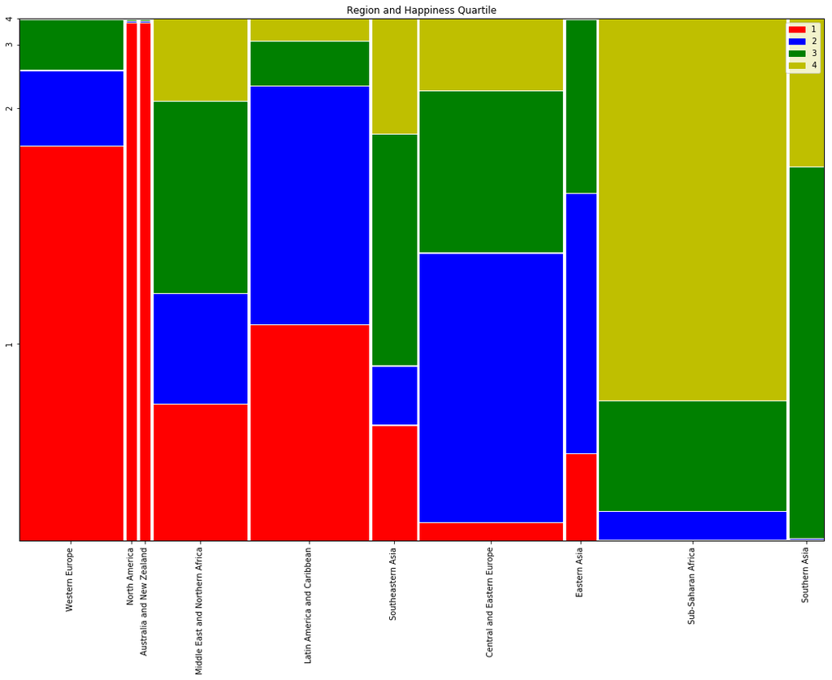

```python
dic_colors = {1: "r", 2: "b",3: "g", 4: "y"}
props = lambda key: {'color': dic_colors[int(key[1])]}

with plt.rc_context():
    plt.rc("figure", figsize=(18,12))
    mosaic(happiness, ['region','quartile'],
           properties = props,
           title = "Region and Happiness Quartile",
           labelizer = lambda k: " ", #k[1], #this is makes it so labels are blank
           #gap=0.0005,
           label_rotation = 90
          )
    legenditems = [(plt.Rectangle((0,0),1,1, color=dic_colors[c]), "%s" %c)
                 for i,c in enumerate(happiness['quartile'].unique().tolist())]
    plt.legend(*zip(*legenditems))
```

##### Explanation:

There appears to be an effect of region on happiness quartile. The mosiac is jagged which indicates that there is an effect on the variable tested and the measure. Sub-Saharan Africa is most likely to be in quartile 4, and North America and Australia and New Zealand are more likely to be in the 1st quartile. If there was no effect of region on happiness quartile the mosiac would not be jagged.

*Links that helped me adjust the mosiac plot:*

link for help with the size of the mosiaac plot: https://stackoverflow.com/questions/28517276/changing-fig-size-with-statsmodel

Got help with the legend: https://stackoverflow.com/questions/57475622/add-a-legend-to-a-mosaic-plot-from-pythons-statsmodels

#### 4) Create a crosstab table assigned to the variable ct using the region and quartile

```python
ct = pd.crosstab(happiness["region"],happiness["quartile"],margins=False)
ct
```

| quartile region | 1 | 2 | 3 | 4 |
| --- | --- | --- | --- | --- |
| Australia and New Zealand | 2 | 0 | 0 | 0 |
| Central and Eastern Europe | 1 | 15 | 9 | 4 |
| Eastern Asia | 1 | 3 | 2 | 0 |
| Latin America and Caribbean | 10 | 11 | 2 | 1 |
| Middle East and Northern Africa | 5 | 4 | 7 | 3 |
| North America | 2 | 0 | 0 | 0 |
| Southeastern Asia | 2 | 1 | 4 | 2 |
| Southern Asia | 0 | 0 | 5 | 2 |
| Sub-Saharan Africa | 0 | 2 | 8 | 28 |
| Western Europe | 16 | 3 | 2 | 0 |

##### Explanation:

I set margins equal to False because I do not want to include marginal total in the heatmap I create in the next step.

#### 5) Create a heatmap visualization of the contigency table created above

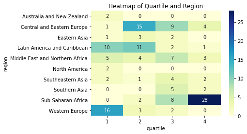

```python
ax=plt.axes()
sns.heatmap(ct,annot=True,  cmap="YlGnBu")
ax.set_title('Heatmap of Quartile and Region')
```

#### Explanation:

From the heatmap above you can see that there are some anomalies. What I mean by this, is that there are some numbers that are higher than expected. The data point that most stands out to me is the Sub-Saharan Africa region. This is consistant with the mosiac plot above. The region is much higher than expected to fall in the 4th quartile.

#### 5) Create a contingency table using the crosstab table created above

```python
chi2, p, dof, ex = chi2_contingency(ct)
print("chi2 = ", chi2)
print("p-val = ", p)
print("degree of freedom = ",dof)
print("Expected:")
pd.DataFrame(ex)
```

```
chi2 =  139.6164992152685
p-val =  3.823562988526965e-17
degree of freedom =  27
Expected:
```

|  | 0 | 1 | 2 | 3 |
| --- | --- | --- | --- | --- |
| 0 | 0.496815 | 0.496815 | 0.496815 | 0.509554 |
| 1 | 7.203822 | 7.203822 | 7.203822 | 7.388535 |
| 2 | 1.490446 | 1.490446 | 1.490446 | 1.528662 |
| 3 | 5.961783 | 5.961783 | 5.961783 | 6.114650 |
| 4 | 4.719745 | 4.719745 | 4.719745 | 4.840764 |
| 5 | 0.496815 | 0.496815 | 0.496815 | 0.509554 |
| 6 | 2.235669 | 2.235669 | 2.235669 | 2.292994 |
| 7 | 1.738854 | 1.738854 | 1.738854 | 1.783439 |
| 8 | 9.439490 | 9.439490 | 9.439490 | 9.681529 |
| 9 | 5.216561 | 5.216561 | 5.216561 | 5.350318 |

##### Explanation:

The chi-squared value explains the difference that exists between the observed counts and the counts expected if there is no relationship in the population being viewed. The output table contains the expected values, which look a lot different than the observed values in the contigency table(which is called ct made in part 4 above).

The chi-squared statistic is 139.6164992152685 which is very big. The associated probability is way less than 0.05. The probability of getting this by chance is very small, as the p-value is 3.823562988526965e-17. This means that this is a statistically significant model because the p-value is less than 0.05. Therefore, we can reject the null hypothesis of no interaction, and say that there is an interaction effect between happeiness score and quartile. As well, this suggests that happiness quartile and region are not independent. This result is consistant with the mosiac plot created above. This further proves that there seems to be an interaction between happiness quartile and region.

#### 6) Use ordinary least square (OLS) regression on region and quartile to get more detail about the regression model using the statsmodels module.

```python
happiness_lm = ols('quartile ~ region', data = happiness).fit()
table = sm.stats.anova_lm(happiness_lm, typ=2)
```

```python
table
```

|  | sum_sq | df | F | PR(>F) |
| --- | --- | --- | --- | --- |
| region | 109.792578 | 9.0 | 20.507953 | 4.714034e-22 |
| Residual | 87.443090 | 147.0 | NaN | NaN |

```python
happiness_lm.summary()
```

OLS Regression Results

| Dep. Variable: | quartile | R-squared: | 0.557 |
| --- | --- | --- | --- |
| Model: | OLS | Adj. R-squared: | 0.530 |
| Method: | Least Squares | F-statistic: | 20.51 |
| Date: | Tue, 22 Oct 2019 | Prob (F-statistic): | 4.71e-22 |
| Time: | 01:31:38 | Log-Likelihood: | -176.83 |
| No. Observations: | 157 | AIC: | 373.7 |
| Df Residuals: | 147 | BIC: | 404.2 |
| Df Model: | 9 |  |  |
| Covariance Type: | nonrobust |  |  |

|  | coef | std err | t | P>\|t\| | [0.025 | 0.975] |
| --- | --- | --- | --- | --- | --- | --- |
| Intercept | 1.0000 | 0.545 | 1.834 | 0.069 | -0.078 | 2.078 |
| region[T.Central and Eastern Europe] | 1.5517 | 0.564 | 2.752 | 0.007 | 0.437 | 2.666 |
| region[T.Eastern Asia] | 1.1667 | 0.630 | 1.853 | 0.066 | -0.078 | 2.411 |
| region[T.Latin America and Caribbean] | 0.7500 | 0.568 | 1.321 | 0.188 | -0.372 | 1.872 |
| region[T.Middle East and Northern Africa] | 1.4211 | 0.573 | 2.478 | 0.014 | 0.288 | 2.554 |
| region[T.North America] | 4.265e-15 | 0.771 | 5.53e-15 | 1.000 | -1.524 | 1.524 |
| region[T.Southeastern Asia] | 1.6667 | 0.603 | 2.764 | 0.006 | 0.475 | 2.858 |
| region[T.Southern Asia] | 2.2857 | 0.618 | 3.696 | 0.000 | 1.064 | 3.508 |
| region[T.Sub-Saharan Africa] | 2.6842 | 0.560 | 4.797 | 0.000 | 1.578 | 3.790 |
| region[T.Western Europe] | 0.3333 | 0.571 | 0.584 | 0.560 | -0.795 | 1.461 |

| Omnibus: | 1.489 | Durbin-Watson: | 1.010 |
| --- | --- | --- | --- |
| Prob(Omnibus): | 0.475 | Jarque-Bera (JB): | 1.078 |
| Skew: | 0.158 | Prob(JB): | 0.583 |
| Kurtosis: | 3.255 | Cond. No. | 30.5 |

Warnings:  
[1] Standard Errors assume that the covariance matrix of the errors is correctly specified.

##### Explanation:

The Prob(F-statistic) is the probability of getting these differences by chance. The Prob(F-statistic) is 4.714034e-22. This means that there appears to be an effect on region on the quartile ranges because Prob(F-statistic) is smaller than 0.05.

# Q4: Use a linear regression to model the relationship between Happiness Score and Family. (5 points)

What does this tell you about the relationship?

You may wish to include a visualization.

#### 1) Review the columns in the happiness DataFrame to see what the Family column is referred to in the DataFrame

```python
happiness.columns
```

```
Index(['Country', 'region', 'Happiness Rank', 'Happiness Score',
       'Lower Confidence Interval', 'Upper Confidence Interval',
       'Economy (GDP per Capita)', 'Family', 'Health (Life Expectancy)',
       'Freedom', 'Trust (Government Corruption)', 'Generosity',
       'Dystopia Residual', 'quartile'],
      dtype='object')
```

##### Explanation:

The Family column is referred to as "Family"

#### 2) Take a subset of the happiness DataFrame and create a DataFrame called fam_v_happiness that has just the Family column and Happiness Score column

```python
fam_v_happiness =happiness[["Family", "Happiness Score"]]
```

#### 3) Use the .corr() method on the fam_v_happiness DataFrame to understand the correlation between the two columns

```python
correlation = fam_v_happiness.corr()
```

##### Explanation:

The correlation between Happiness Score and Family is 0.739252. This means that Happiness Score and Family have a strong positive relationship. I am going to continue to investigate this relationship using visualizations.

#### 4) Use the scatter pairplot and a regression pairplot to review the relationship between Happiness Score and Family

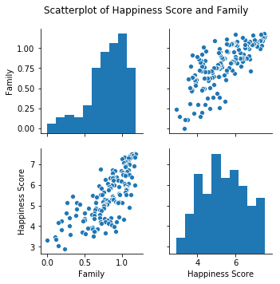

```python
g2=sns.pairplot(happiness,
             vars = ['Family','Happiness Score'],
             kind = "scatter")
g2.fig.subplots_adjust(top=0.9)
g2.fig.suptitle("Scatterplot of Happiness Score and Family", fontsize=12)
```

##### Explanation:

From the Scatterplot you can see that their appears to be a positive correlation between Family and Happiness Score because as Happiness Score increases so does Family (and vice versa).

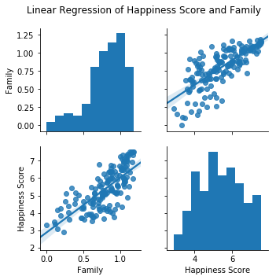

```python
g2 = sns.pairplot(happiness,
             vars = ['Family','Happiness Score'],
            kind = "reg")
g2.fig.subplots_adjust(top=0.9)
g2.fig.suptitle("Linear Regression of Happiness Score and Family", fontsize=12)
```

##### Explanation:

From this linear regression you see that their appears to be a positive correlation between Family and Happiness Score. The points are clustered around the regression line, and Family is increasing as Happiness Score increases.

#### 5) Use ordinary least square (OLS) regression on Happiness Score and Family to get more detail about the regression model using the statsmodels module.

```python
model1 = smf.ols(" Q('Happiness Score') ~ Family", data=happiness).fit()
model1.summary()
```

OLS Regression Results

| Dep. Variable: | Q('Happiness Score') | R-squared: | 0.546 |
| --- | --- | --- | --- |
| Model: | OLS | Adj. R-squared: | 0.544 |
| Method: | Least Squares | F-statistic: | 186.8 |
| Date: | Tue, 22 Oct 2019 | Prob (F-statistic): | 2.09e-28 |
| Time: | 01:31:43 | Log-Likelihood: | -181.00 |
| No. Observations: | 157 | AIC: | 366.0 |
| Df Residuals: | 155 | BIC: | 372.1 |
| Df Model: | 1 |  |  |
| Covariance Type: | nonrobust |  |  |

|  | coef | std err | t | P>\|t\| | [0.025 | 0.975] |
| --- | --- | --- | --- | --- | --- | --- |
| Intercept | 2.8708 | 0.194 | 14.813 | 0.000 | 2.488 | 3.254 |
| Family | 3.1645 | 0.232 | 13.667 | 0.000 | 2.707 | 3.622 |

| Omnibus: | 5.248 | Durbin-Watson: | 1.108 |
| --- | --- | --- | --- |
| Prob(Omnibus): | 0.073 | Jarque-Bera (JB): | 4.375 |
| Skew: | -0.313 | Prob(JB): | 0.112 |
| Kurtosis: | 2.475 | Cond. No. | 6.24 |

Warnings:  
[1] Standard Errors assume that the covariance matrix of the errors is correctly specified.

##### Explanation:

The R-squared vaule is how much of overall variance is explained by linear expression/model. 54.6 percent of overall variance is explained by this model. However, the p-value, called "Prob (F-statistic)" in the output is 2.09e-28 which is less than 0.05. This means that this is a statistically significant model, and we can reject the null hypothesis, because the probability of getting the F-Statistic by chance is less than 0.05.

The P>|t| means that the coeffcients for the model are statistically significant. If this value is smaller than 0.05, than the model is statistically significant. Here both coefficents are smaller than 0.05( both are 0.000); Therefore, you can formulate a regression equation from these coeffcients.

Since the estimates for the parameters of the model are statistically significant, we can use the equation Happiness Score = 3.1645 * Family + 2.8708 to predict the value of Happiness Score given a value for Family.

#### 6) Now create JointGrid Visualization that show the p-value and personr score for Happiness Score Versus Family

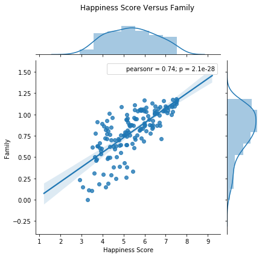

```python
# put your code here
column = "Family"
g2 = sns.JointGrid(data=subset,x='Happiness Score',y=column)
g2.plot(sns.regplot, sns.distplot)
g2.annotate(stats.pearsonr)
g2.fig.subplots_adjust(top=0.9)
g2.fig.suptitle("Happiness Score Versus Family", fontsize=12)

#interepret the regression
```

##### Explanation:

Happiness Sore and Family have a correlation. This is because as happiness score increases so does Family. The personr value calculated shows if the two variables have a correlation. The personr for Happiness Score versus Family is 0.74, indicating that there is a strong linear relationship/correlation present. The p-value of 2.1e-28, which is less than 0.05, indicates that this is a statistically significant model.

#### 7) Use Seaborn to create a lmplot. This is a Linear Regression plot with regression line for Happiness Sore versus Family

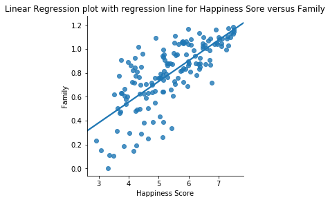

```python
sns.lmplot(x="Happiness Score", y="Family", data= subset,
           ci=None, palette="muted", height=4)
plt.title("Linear Regression plot with regression line for Happiness Sore versus Family")
```

##### Explanation:

This is another plot that shows the regression. As happiness score increases Family increases. The points are scattered around this line, and there looks to be a linear relationship present.

# Q5: Do happiness scores vary significantly between regions? Which region has the highest mean happiness score? (5 points)

You may wish to include a visualization. Hint: ANOVA might help here.

#### 1) Use ordinary least square (OLS) regression on Happiness Score and Region to get more detail about the regression model using the statsmodels module

```python
# put your code here

model1 = smf.ols(" Q('Happiness Score') ~ region", data=happiness).fit()
model1.summary()
```

OLS Regression Results

| Dep. Variable: | Q('Happiness Score') | R-squared: | 0.623 |
| --- | --- | --- | --- |
| Model: | OLS | Adj. R-squared: | 0.600 |
| Method: | Least Squares | F-statistic: | 27.00 |
| Date: | Tue, 22 Oct 2019 | Prob (F-statistic): | 4.57e-27 |
| Time: | 01:31:47 | Log-Likelihood: | -166.48 |
| No. Observations: | 157 | AIC: | 353.0 |
| Df Residuals: | 147 | BIC: | 383.5 |
| Df Model: | 9 |  |  |
| Covariance Type: | nonrobust |  |  |

|  | coef | std err | t | P>\|t\| | [0.025 | 0.975] |
| --- | --- | --- | --- | --- | --- | --- |
| Intercept | 7.3235 | 0.511 | 14.344 | 0.000 | 6.314 | 8.333 |
| region[T.Central and Eastern Europe] | -1.9528 | 0.528 | -3.699 | 0.000 | -2.996 | -0.910 |
| region[T.Eastern Asia] | -1.6993 | 0.590 | -2.882 | 0.005 | -2.864 | -0.534 |
| region[T.Latin America and Caribbean] | -1.2218 | 0.531 | -2.299 | 0.023 | -2.272 | -0.172 |
| region[T.Middle East and Northern Africa] | -1.9374 | 0.537 | -3.609 | 0.000 | -2.998 | -0.877 |
| region[T.North America] | -0.0695 | 0.722 | -0.096 | 0.923 | -1.496 | 1.357 |
| region[T.Southeastern Asia] | -1.9846 | 0.564 | -3.516 | 0.001 | -3.100 | -0.869 |
| region[T.Southern Asia] | -2.7602 | 0.579 | -4.768 | 0.000 | -3.904 | -1.616 |
| region[T.Sub-Saharan Africa] | -3.1871 | 0.524 | -6.084 | 0.000 | -4.222 | -2.152 |
| region[T.Western Europe] | -0.6378 | 0.534 | -1.194 | 0.235 | -1.694 | 0.418 |

| Omnibus: | 7.157 | Durbin-Watson: | 1.255 |
| --- | --- | --- | --- |
| Prob(Omnibus): | 0.028 | Jarque-Bera (JB): | 7.064 |
| Skew: | -0.417 | Prob(JB): | 0.0292 |
| Kurtosis: | 3.619 | Cond. No. | 30.5 |

Warnings:  
[1] Standard Errors assume that the covariance matrix of the errors is correctly specified.

```python
table = sm.stats.anova_lm(model1, typ=2) # Type 2 ANOVA DataFrame: no interaction effect
table
```

|  | sum_sq | df | F | PR(>F) |
| --- | --- | --- | --- | --- |
| region | 126.691462 | 9.0 | 26.999543 | 4.573860e-27 |
| Residual | 76.641811 | 147.0 | NaN | NaN |

##### Explanation:

In general, Anova shows if there is a difference or not between the two variables. The R-squared value is how much of overall variance is explained by linear expression/model. According to the OLS regression results, 62.3 percent of overall variance is explained by this model. However, the p-value, called "Prob (F-statistic)" in the output is 4.57e-27 which is less than 0.05. This means that this is a statistically significant model because the probability of getting the F-Statistic by chance is less than 0.05. Therefore, there is an effect, or significant difference on region on Happiness Score.

#### 2) Find the region that has the highest Mean Happiness Score

```python
happiness_score_v_region =  happiness[["Happiness Score","region"]]
```

```python
mean_score =happiness_score_v_region.groupby("region")["Happiness Score"].mean().reset_index(name ="mean_happiness_score")
mean_score
```

|  | region | mean_happiness_score |
| --- | --- | --- |
| 0 | Australia and New Zealand | 7.323500 |
| 1 | Central and Eastern Europe | 5.370690 |
| 2 | Eastern Asia | 5.624167 |
| 3 | Latin America and Caribbean | 6.101750 |
| 4 | Middle East and Northern Africa | 5.386053 |
| 5 | North America | 7.254000 |
| 6 | Southeastern Asia | 5.338889 |
| 7 | Southern Asia | 4.563286 |
| 8 | Sub-Saharan Africa | 4.136421 |
| 9 | Western Europe | 6.685667 |

##### Explanation:

First I created a DataFrame called happiness_score_v_region that only has the columns Happiness Score and region. This is a subset of the happiness DataFrame. I then did groupby for region, and calculated the mean Happiness Score for every region. I reset the index to be called mean_happiness_score, and assigned this new DataFrame to the variable mean_score.

The mean_score DataFrame has two columns: region and mean_happiness_score. The mean_happiness_score column will have the mean Happiness Score for every region in the DataFrame.

```python
region_highest_happiness_score =mean_score[mean_score["mean_happiness_score"] == mean_score["mean_happiness_score"].max()]
```

```python
region_highest_happiness_score
```

|  | region | mean_happiness_score |
| --- | --- | --- |
| 0 | Australia and New Zealand | 7.3235 |

##### Explanation:

I filtered the mean_score DataFrame to show the region with the highest mean_happiness_score. I found that the region with the highest mean_happiness_score is Australia and New Zealand. This region has a mean happiness score of 7.3235.

#### 3) Create a Heatmap of all the happiness scores their associated regions

```python
happiness_score_v_region =  happiness[["Happiness Score","region"]]
```

```python
happiness_score_v_region["Happiness Score"] = happiness_score_v_region["Happiness Score"]//1
```

##### Explanation:

Do a floor divide on the happiness scores so that happiness scores do not have a decimal place and they are whole numbers. This will create buckets of happiness scores from 2.0 - 7.0. Although, this is rounding down in many cases, it gives a good general sense of the happiness scores for each region, and allows me to plot this information in a much more readable and understandable way.

```python
ct = pd.crosstab(happiness_score_v_region["region"],happiness_score_v_region["Happiness Score"],margins=False)
```

```python
ct
```

| Happiness Score region | 2.0 | 3.0 | 4.0 | 5.0 | 6.0 | 7.0 |
| --- | --- | --- | --- | --- | --- | --- |
| Australia and New Zealand | 0 | 0 | 0 | 0 | 0 | 2 |
| Central and Eastern Europe | 0 | 0 | 6 | 21 | 2 | 0 |
| Eastern Asia | 0 | 0 | 1 | 4 | 1 | 0 |
| Latin America and Caribbean | 0 | 0 | 2 | 8 | 12 | 2 |
| Middle East and Northern Africa | 0 | 2 | 4 | 6 | 6 | 1 |
| North America | 0 | 0 | 0 | 0 | 0 | 2 |
| Southeastern Asia | 0 | 1 | 2 | 3 | 3 | 0 |
| Southern Asia | 0 | 1 | 4 | 2 | 0 | 0 |
| Sub-Saharan Africa | 1 | 16 | 18 | 3 | 0 | 0 |
| Western Europe | 0 | 0 | 0 | 5 | 8 | 8 |

##### Explanation:

Create a contingency table using pd.crosstab for region and Happiness Score called ct.

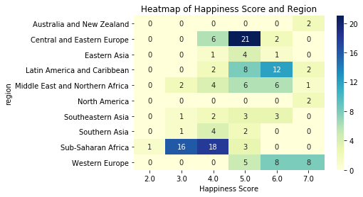

```python
ax = plt.axes()
sns.heatmap(ct,annot =True, cmap="YlGnBu")

ax.set_title('Heatmap of Happiness Score and Region')
```

##### Explanation:

From the heatmap above you can see there are some anomalies. The happiness scores vary depending on the region. For example, Sub-Saharan Africa has more countries that fall in the happiness score bucket of 4.0. As well Latin America and Caribbean have a happiness score of 6.0. Central and Eastern Europe have many countries that have a happiness score of 5.0.

#### 4) Create a boxplot of happiness scores and regions

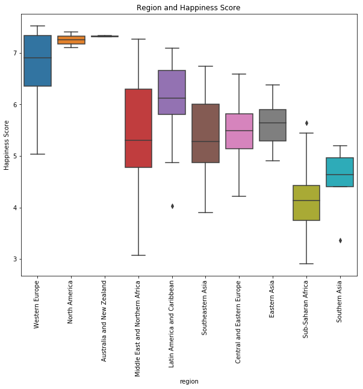

```python
with plt.rc_context():
    plt.rc("figure", figsize=(10,8))
    ax = sns.boxplot("region",y="Happiness Score",data=happiness)
    plt.setp(ax.get_xticklabels(), rotation=90)
    ax.set_title("Region and Happiness Score")
```

#### Explanation

There appears to be a difference between region and happiness score. The boxplots shown vary depending on the region, further demonstrating that there is a difference between happiness scores and the regions. Happiness scores seems to vary depending on the region.

# Q6: Which Eastern Asian country has the lowest happiness score. Comment on the influence that that country has on the relationship between Happiness and Economy.

Hint: you may want to look at the residuals of a regression between Happiness and Economy.

#### 1) Filter the happiness DataFrame to only show where region == "Eastern Asia"

```python
eastern_asia_countries = happiness[(happiness["region"]=="Eastern Asia")]
eastern_asia_countries
```

|  | Country | region | Happiness Rank | Happiness Score | Lower Confidence Interval | Upper Confidence Interval | Economy (GDP per Capita) | Family | Health (Life Expectancy) | Freedom | Trust (Government Corruption) | Generosity | Dystopia Residual | quartile |
| --- | --- | --- | --- | --- | --- | --- | --- | --- | --- | --- | --- | --- | --- | --- |
| 34 | Taiwan | Eastern Asia | 34 | 6.379 | 6.305 | 6.453 | 1.39729 | 0.92624 | 0.79565 | 0.32377 | 0.06630 | 0.25495 | 2.61523 | 1 |
| 52 | Japan | Eastern Asia | 53 | 5.921 | 5.850 | 5.992 | 1.38007 | 1.06054 | 0.91491 | 0.46761 | 0.18985 | 0.10224 | 1.80584 | 2 |
| 57 | South Korea | Eastern Asia | 57 | 5.835 | 5.747 | 5.923 | 1.35948 | 0.72194 | 0.88645 | 0.25168 | 0.07716 | 0.18824 | 2.35015 | 2 |
| 74 | Hong Kong | Eastern Asia | 75 | 5.458 | 5.362 | 5.554 | 1.51070 | 0.87021 | 0.95277 | 0.48079 | 0.31647 | 0.40097 | 0.92614 | 2 |
| 82 | China | Eastern Asia | 83 | 5.245 | 5.199 | 5.291 | 1.02780 | 0.79381 | 0.73561 | 0.44012 | 0.02745 | 0.04959 | 2.17087 | 3 |
| 100 | Mongolia | Eastern Asia | 101 | 4.907 | 4.838 | 4.976 | 0.98853 | 1.08983 | 0.55469 | 0.35972 | 0.03285 | 0.34539 | 1.53586 | 3 |

##### Explanation:

The question is asking about Eastern Asian Countries so I will need a filtered DataFrame to conduct some of the analysis. Here I am filtering the happiness DataFrame to only show where region == "Eastern Asia", and I assign this DataFrame to the variable eastern_asia_countries.

#### 2) I will use eastern_asia_countries DataFrame to find the country with the lowest Happiness Score. Then, I will assign this filtered DataFrame to the variable country_lowest_happiness_score. I will also assign the index of this row to the variable index_of_country_with_lowest_happiness_score .

```python
country_lowest_happiness_score = eastern_asia_countries[eastern_asia_countries["Happiness Score"] == eastern_asia_countries["Happiness Score"].min()]
index_of_country_with_lowest_happiness_score = country_lowest_happiness_score.index[0]
country_lowest_happiness_score
```

|  | Country | region | Happiness Rank | Happiness Score | Lower Confidence Interval | Upper Confidence Interval | Economy (GDP per Capita) | Family | Health (Life Expectancy) | Freedom | Trust (Government Corruption) | Generosity | Dystopia Residual | quartile |
| --- | --- | --- | --- | --- | --- | --- | --- | --- | --- | --- | --- | --- | --- | --- |
| 100 | Mongolia | Eastern Asia | 101 | 4.907 | 4.838 | 4.976 | 0.98853 | 1.08983 | 0.55469 | 0.35972 | 0.03285 | 0.34539 | 1.53586 | 3 |

```python
index_of_country_with_lowest_happiness_score
```

```
100
```

##### Explanation:

The country in Eastern Asia with the lowest happiness score is Mongolia. Mongolia has a Happiness Score of 4.907. The Economy (GDP per Capita) is 0.98853. The index that refers to this row in the DataFrame is 100.

#### 3) On the DataFrame eastern_asia_countries, use the ordinary least square (OLS) regression on Happiness Score and Economy (GDP per Capita) to get more details about the regression model using the statsmodels module. I am using eastern_asia_countries and not happiness because the question refers to Eastern Asian Countries.

```python
ecnomoy_v_happiness = smf.ols("Q('Happiness Score') ~ Q('Economy (GDP per Capita)')",data = eastern_asia_countries).fit()
ecnomoy_v_happiness
```

```
<statsmodels.regression.linear_model.RegressionResultsWrapper at 0x7f1ec6fdd630>
```

#### 4) Use economy_v_happiness, which contains the ordinary least square (OLS) regression model returned from the statsmodels module object, and create an influence plot. The influence plot will help me decipher the influence of every point by looking at residual and leverage. I want to base the size of the points on cooks distance (criterion == 'cooks').

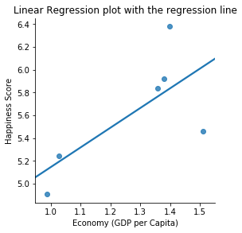

```python
sns.lmplot(x="Economy (GDP per Capita)", y="Happiness Score", data= eastern_asia_countries,
           ci=None, palette="muted", height=4)
plt.title("Linear Regression plot with the regression line")
```

```
The rsquared value is 0.5005117806489173
```

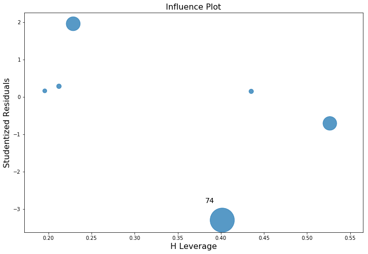

```python
print("The rsquared value is " + str(ecnomoy_v_happiness.rsquared))
fig, ax = plt.subplots(figsize=(12,8))
# lm2 = sm.OLS(y2, sm.add_constant(x2)).fit()
#fig = sm.graphics.influence_plot(ecnomoy_v_happiness, ax= ax, criterion="cooks")
fig = sm.graphics.influence_plot(ecnomoy_v_happiness, ax= ax, criterion="cooks",alpha=0.05)
```

##### Explanation:

Determining the influence from an outlier is difficult to do for every single point. In order to determine influence we look at the effect of taking every point out, and examine how it would change the result. In other words, for every point, if we took this point out, how would it influence the estimate of coefficents?

As you can see, the index value of 74 has a large negative residual, and the point does not appear to have significant leverage. The index value of 74 is not referring to the country Mongolia. I am going to look at the cook's distance values to further investigate the influence of Mongolia, but from the influence plot it does not appear to have a significant influence on the regression because it is not labeled.

#### 6. use the get_influence() and than the summary_frame() to get statistics on the statsmodels.regression.linear_model object called ecnomoy_v_happiness

```python
infl = ecnomoy_v_happiness.get_influence()
```

##### Explanation:

Using ecnomoy_v_happiness assign an influence object to the variable infl.

```python
sm_fr = infl.summary_frame()
sm_fr
```

|  | dfb_Intercept | dfb_Q('Economy (GDP per Capita)') | cooks_d | standard_resid | hat_diag | dffits_internal | student_resid | dffits |
| --- | --- | --- | --- | --- | --- | --- | --- | --- |
| 34 | -0.409707 | 0.554275 | 0.332119 | 1.496467 | 0.228760 | 0.815008 | 1.953437 | 1.063884 |
| 52 | -0.047366 | 0.067917 | 0.013956 | 0.321895 | 0.212215 | 0.167070 | 0.282452 | 0.146598 |
| 57 | -0.018989 | 0.030406 | 0.004108 | 0.183715 | 0.195790 | 0.090647 | 0.159777 | 0.078836 |
| 74 | 1.777152 | -2.065822 | 1.052010 | -1.770514 | 0.401627 | -1.450524 | -3.296715 | -2.700890 |
| 82 | 0.112008 | -0.101073 | 0.010959 | 0.168651 | 0.435212 | 0.148046 | 0.146578 | 0.128670 |
| 100 | -0.675322 | 0.618486 | 0.319529 | -0.758266 | 0.526396 | -0.799411 | -0.709660 | -0.748167 |

##### Explanation:

I used the infl variable and invoked summary_frame() to ceate a DataFrame called sm_fr that contains useful statistics. The column called cooks_d is the Cook's distance values for every observation. Cook's distance measures the effect of deleting a given observation. The rows in the DataFrame that have a Cook's distance value that is greater than 1 have influence on the results.

#### 7. Find all rows in sm_fr that have a cooks_d greater than 1

```python
above_1 = sm_fr[sm_fr["cooks_d"] >1]
above_1
```

|  | dfb_Intercept | dfb_Q('Economy (GDP per Capita)') | cooks_d | standard_resid | hat_diag | dffits_internal | student_resid | dffits |
| --- | --- | --- | --- | --- | --- | --- | --- | --- |
| 74 | 1.777152 | -2.065822 | 1.05201 | -1.770514 | 0.401627 | -1.450524 | -3.296715 | -2.70089 |

```python
index_above_1 = above_1.index.values[0]
```

##### Explanation:

There is one row in the DataFrame that has a cooks_d greater than 1. This is the row with an index of 74, and this row has a cooks distance (shown under cooks_d) of 1.05201. I got the index value of the row that is greater than 1 and assigned it to the variable index_above_1. I did this because I am going to use this index to get information about this country from the eastern_asia_countries DataFrame.

```python
index = above_1.index.values[0]
eastern_asia_countries.loc[index_above_1]
```

```
Country                             Hong Kong
region                           Eastern Asia
Happiness Rank                             75
Happiness Score                         5.458
Lower Confidence Interval               5.362
Upper Confidence Interval               5.554
Economy (GDP per Capita)               1.5107
Family                                0.87021
Health (Life Expectancy)              0.95277
Freedom                               0.48079
Trust (Government Corruption)         0.31647
Generosity                            0.40097
Dystopia Residual                     0.92614
quartile                                    2
Name: 74, dtype: object
```

##### Explanation:

I used .loc and index_above_1 to get the country in eastern_asia_countries that has a cooks distance of greater than 1. This country is Hong Kong. The Happiness Score in this country is 5.458 and the Economy (GDP per Capita) is 1.5107. This country has influence on the relationship between Happiness Score and Economy because the Cook's distance measure is greater than 1.

#### 7. Find Mangolia's statistics in sm_fr using Mangolia's index, that is assigned to the variable index_of_country_with_lowest_happiness_score

```python
infl = ecnomoy_v_happiness.get_influence()
sm_fr = infl.summary_frame()
sm_fr.loc[index_of_country_with_lowest_happiness_score]
```

```
dfb_Intercept                       -0.675322
dfb_Q('Economy (GDP per Capita)')    0.618486
cooks_d                              0.319529
standard_resid                      -0.758266
hat_diag                             0.526396
dffits_internal                     -0.799411
student_resid                       -0.709660
dffits                              -0.748167
Name: 100, dtype: float64
```

##### Explanation:

I used .loc and index_of_country_with_lowest_happiness_score to get Mongolia's statistics from the sm_fr DataFrame. Mongolia has a cooks_d of 0.319529. This Cook's distance measure is not greater than 1, so this country does not have a significant influence on the regression results of Happiness Score and Economy.

Examining the ratio of Happiness Score and Economy can help explain why Mongolia does not have much influence on the regression. For example, Hong kong has an Economy value that is high comparativity to the Happiness Score. On the other hand, Mongolia has a low Happiness Score and a low Economy, so this may be why this point is not as influential on the regression line.

#### 8. You can also extract the Cook's Distance values and their associated p-values from the influence object called infl. (i just wanted to show that there was another way to get the cook_distance values)

```python
c,p = infl.cooks_distance
df = pd.DataFrame.from_dict({'cooks_distance':c,'pvalue':p})
df
```

|  | cooks_distance | pvalue |
| --- | --- | --- |
| 0 | 0.332119 | 0.735459 |
| 1 | 0.013956 | 0.986189 |
| 2 | 0.004108 | 0.995904 |
| 3 | 1.052010 | 0.429426 |
| 4 | 0.010959 | 0.989131 |
| 5 | 0.319529 | 0.743465 |

```python
new = eastern_asia_countries.reset_index()
new
```

|  | index | Country | region | Happiness Rank | Happiness Score | Lower Confidence Interval | Upper Confidence Interval | Economy (GDP per Capita) | Family | Health (Life Expectancy) | Freedom | Trust (Government Corruption) | Generosity | Dystopia Residual | quartile |
| --- | --- | --- | --- | --- | --- | --- | --- | --- | --- | --- | --- | --- | --- | --- | --- |
| 0 | 34 | Taiwan | Eastern Asia | 34 | 6.379 | 6.305 | 6.453 | 1.39729 | 0.92624 | 0.79565 | 0.32377 | 0.06630 | 0.25495 | 2.61523 | 1 |
| 1 | 52 | Japan | Eastern Asia | 53 | 5.921 | 5.850 | 5.992 | 1.38007 | 1.06054 | 0.91491 | 0.46761 | 0.18985 | 0.10224 | 1.80584 | 2 |
| 2 | 57 | South Korea | Eastern Asia | 57 | 5.835 | 5.747 | 5.923 | 1.35948 | 0.72194 | 0.88645 | 0.25168 | 0.07716 | 0.18824 | 2.35015 | 2 |
| 3 | 74 | Hong Kong | Eastern Asia | 75 | 5.458 | 5.362 | 5.554 | 1.51070 | 0.87021 | 0.95277 | 0.48079 | 0.31647 | 0.40097 | 0.92614 | 2 |
| 4 | 82 | China | Eastern Asia | 83 | 5.245 | 5.199 | 5.291 | 1.02780 | 0.79381 | 0.73561 | 0.44012 | 0.02745 | 0.04959 | 2.17087 | 3 |
| 5 | 100 | Mongolia | Eastern Asia | 101 | 4.907 | 4.838 | 4.976 | 0.98853 | 1.08983 | 0.55469 | 0.35972 | 0.03285 | 0.34539 | 1.53586 | 3 |

```python
corresponding_index_in_df =new[new["index"] == index_of_country_with_lowest_happiness_score].index[0]
```

```python
df.iloc[corresponding_index_in_df]
```

```
cooks_distance    0.319529
pvalue            0.743465
Name: 5, dtype: float64
```

```python
country_as_index = df.set_index(eastern_asia_countries["Country"])
country_as_index
```

| Country | cooks_distance | pvalue |
| --- | --- | --- |
| Taiwan | 0.332119 | 0.735459 |
| Japan | 0.013956 | 0.986189 |
| South Korea | 0.004108 | 0.995904 |
| Hong Kong | 1.052010 | 0.429426 |
| China | 0.010959 | 0.989131 |
| Mongolia | 0.319529 | 0.743465 |

```python
name_of_country =country_lowest_happiness_score["Country"].values[0]
country_as_index.loc[country_lowest_happiness_score["Country"].values[0]]
```

```
cooks_distance    0.319529
pvalue            0.743465
Name: Mongolia, dtype: float64
```

#### Explanation:

I reset the index of eastern_asia_countries so that the index of each row would match up to df (the DataFrame with the columns cooks_distance and pvalue). I assigned this DataFrame to the variable new. After this I found the row that is equal to Mongolia by filtering the DataFrame new, where the index column is equal to index_of_country_with_lowest_happiness_score (Mongolia's index). I then found the new index of Mongolia, which will be the same/correspond directly to the index in df. I assigned this index to the variable corresponding_index_in_df. I used iloc and corresponding_index_in_df to find the row that has Mongolia's cooks_distance and pvalue in df.

Another way to get Mongolia's cooks_distance and pvalue from df is to do df.set_index(eastern_asia_countries["Country"]). I assigned this new DataFrame to the variable country_as_index and used .loc to get the row whose index is the same as the string name_of_country (name_of_country is a string with name of the country with the lowest happiness score).

I found that Mongolia has a pvalue of 0.743465 and the cooks distance is 0.319529. This is consistant with the cooks distance I found in the DataFrame sm_fr for Mongolia. Again, Mongolia's Cook's distance measure of 0.319529 shows that this observation does not have much influence on the regression results because it is not greater than 1.

## Please submit your completed notebook in .HTML format via Canvas